# REDStat Code Snippets

Ahmed SOROUR

2024-01-28

```r
# install.packages("BDSA")
# library(tidyverse)
# library(dplyr)
# library(BSDA)
# library(ggplot2)
pacman::p_load(data.table, rio, here, dplyr, epikit, janitor, lubridate, ggplot2, crosstable, stringr, gtsummary, flextable, Hmisc, scales, incidence, tidyverse, kableExtra, knitr, descriptr, NHANES, NHSRdatasets, lattice, BSDA, medicaldata)
```

## WEEK 1

### WK1-TOPIC2-PART 1 - distribution - freqyency table

here we can create * Frequency table - using function from descriptr apparently - for pulse - distributed in bins - with frequncy / cumulative freqncy / cumulative percent

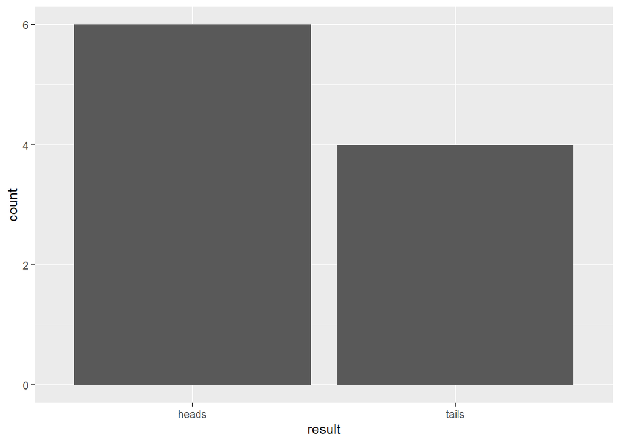

```r
## Slide 6: bar chart for categorical variables

# First, we create a vector of outcomes from tossing a coin
coin_tosses <- c("heads", "heads", "heads", "heads", "heads", "heads",
                 "tails", "tails", "tails", "tails")

# Now we turn this vector into a dataframe for better plotting
# The resulting dataframe has one column
coin_tosses <- as.data.frame(coin_tosses)

# And here we give the dataframe column a name (result)
colnames(coin_tosses) <- c("result")

# Now we create a bar chart
coin_tosses %>%
  ggplot(aes(x = result)) +
  geom_bar()
```

```r
## Slide 9: frequency table for a continuous variable
# we'll use pulse data from the NHANES dataset (and package)
# (10k observations of pulse)

# Let's load the data in first
data(NHANES)

# quite a clunky frequency table, using base R functions
# (gives you the frequency of each value)
table(NHANES$Pulse)
```

```
##
##  40  42  44  46  48  50  52  54  56  58  60  62  64  66  68  70  72  74  76  78
##   9   4  12   9  38  81  97 158 194 295 399 387 471 484 554 598 587 536 551 445
##  80  82  84  86  88  90  92  94  96  98 100 102 104 106 108 110 112 114 116 118
## 451 428 346 298 241 195 150 125 110  68  67  51  41  17  17   6  11   5   7   5
## 120 122 124 126 128 134 136
##   6   3   1   1   2   1   1
```

```r
# Using the code below, you can ask R to divide data into bins
# and provide frequencies by bin
bins <- seq(40, 140, by=5)
scores <- cut(NHANES$Pulse, bins)
table(scores)
```

```
## scores
##   (40,45]   (45,50]   (50,55]   (55,60]   (60,65]   (65,70]   (70,75]   (75,80]
##        16       128       255       888       858      1636      1123      1447
##   (80,85]   (85,90]   (90,95]  (95,100] (100,105] (105,110] (110,115] (115,120]
##       774       734       275       245        92        40        16        18
## (120,125] (125,130] (130,135] (135,140]
##         4         3         1         1
```

```r
# The resulting table is closer to what we'd like, but not great for printing.

# The descriptr package gives us a function for a slightly better frequency table:
ds_freq_table(NHANES, Pulse, 10) # This is the table you saw on slide 9.
```

```
##                               Variable: Pulse
## |-------------------------------------------------------------------------|
## |     Bins      | Frequency | Cum Frequency |   Percent    | Cum Percent  |
## |-------------------------------------------------------------------------|
## |  40   - 49.6  |    72     |      72       |     0.84     |     0.84     |
## |-------------------------------------------------------------------------|
## | 49.6  - 59.2  |    825    |      897      |     9.63     |    10.48     |
## |-------------------------------------------------------------------------|
## | 59.2  - 68.8  |   2295    |     3192      |     26.8     |    37.28     |
## |-------------------------------------------------------------------------|
## | 68.8  - 78.4  |   2717    |     5909      |    31.73     |    69.01     |
## |-------------------------------------------------------------------------|
## | 78.4  -  88   |   1523    |     7432      |    17.79     |    86.79     |
## |-------------------------------------------------------------------------|
## |  88   - 97.6  |    821    |     8253      |     9.59     |    96.38     |
## |-------------------------------------------------------------------------|
## | 97.6  - 107.2 |    244    |     8497      |     2.85     |    99.23     |
## |-------------------------------------------------------------------------|
## | 107.2 - 116.8 |    46     |     8543      |     0.54     |    99.77     |
## |-------------------------------------------------------------------------|
## | 116.8 - 126.4 |    16     |     8559      |     0.19     |    99.95     |
## |-------------------------------------------------------------------------|
## | 126.4 -  136  |     4     |     8563      |     0.05     |     100      |
## |-------------------------------------------------------------------------|
## |    Missing    |   1437    |       -       |    14.37     |      -       |
## |-------------------------------------------------------------------------|
## |     Total     |   10000   |       -       |    100.00    |      -       |
## |-------------------------------------------------------------------------|
```

### WK1-TOPIC2-PART 2 - measures of central tendency

here we can measures of central tendency it is going beyond tables  
* averages – mean / median / mode * spread – how close to the center **variance, standard deviation, interquantile ranges** * HERE - mode is created as**function** and you can create it and learn how to make a funciton * note that to calcuate the median or mean - you need to remove the NA values - using fucntino na.rm = TTUE

```r
# Let's load the NHANES data
data(NHANES)

# Let's use R to calculate measures of central tendency in the Pulse variable

# Mean ----
# Remember from the frequency table that we do have missing values
# We need to tell R explicitly to remove them from the mean calculation
# mean is x bar  - sum all the x(es) and devide this by N (number of data ponts you had in your dataset)
# Otherwise we will get NA as the outcome
mean_pulse <- mean(NHANES$Pulse, na.rm = TRUE)
mean_pulse
```

```
## [1] 73.55973
```

```r
# Median ----
median_pulse <- median(NHANES$Pulse, na.rm = TRUE)
median_pulse
```

```
## [1] 72
```

```r
# Mode ----
# There is no ready-made function in R to calculate the mode
# We can write our own function (optional)
# This function comes from StackOverflow:
# https://stackoverflow.com/questions/2547402/how-to-find-the-statistical-mode
# Understanding the details of it is beyond the scope of this course
# But if you are curious about it, please feel free to ask Kasia

calculate_mode <- function(x) {
  uniqx <- unique(na.omit(x))
  # this line creates a vector of unique values of x (in our case, Pulse)
  uniqx[which.max(tabulate(match(x, uniqx)))]
  # this line creates a table of the frequency of each unique value
  # and then picks the value with the highest frequency
}

mode_pulse <- calculate_mode(NHANES$Pulse)
mode_pulse
```

```
## [1] 70
```

### WK1-TOPIC2-PART 3 - measures of spread -

how similar or varied - over narrow or wide rrange two main measure (SD or IQR)

to build up the SD valcuation * first you calcuate deviation >> distance of a single o servation from the mean * step 2: Variacne >> s2 average of squares of the devaition * sd <- square root of the variance * so devaition >> square >> square root  
* interquartile is relationship with the **median** not the mean  
* IQR when plotted using boxplot >> median would be the value in the center (not the mean)

- When you tuse SD and when to use IQR ** mean & SD is more to normal distribution ** IQR and median is better with skewed and extreme outliers

```r
# Standard deviation
sd_pulse <- sd(NHANES$Pulse, na.rm = TRUE)
sd_pulse
```

```
## [1] 12.15542
```

```r
# Interquartile range
iqr_pulse <- IQR(NHANES$Pulse, na.rm = TRUE)
iqr_pulse
```

```
## [1] 18
```

### WK1-TOPIC2-PART 4 - frequency distribution - visualization

- Notice that we put Pulse on the y-axis, and level of physical activity on the x axis
- to stick with the convention **that boxplots are vertical**
- We’ve added a title and a label to the x-axis
- violin plot and wuffle plot >> if you like to plot distributions more

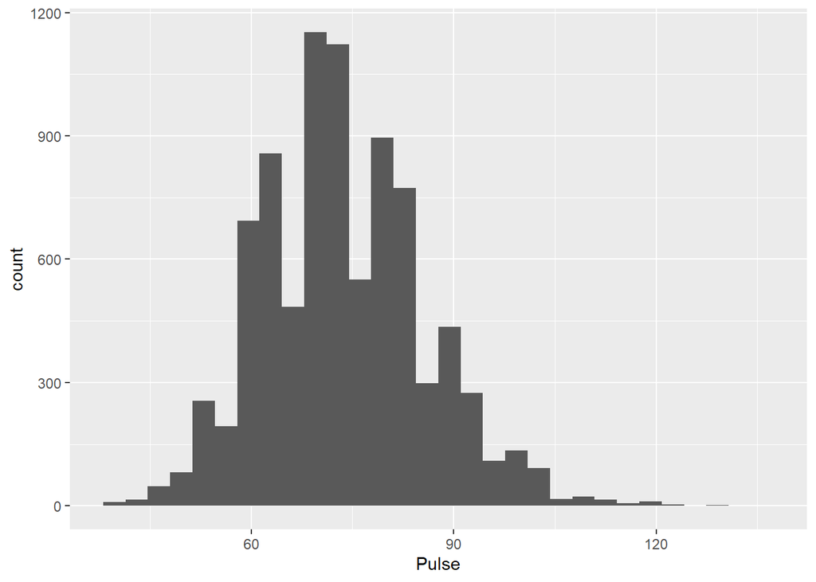

```r
# simplest histogram ----
NHANES %>%
  ggplot(aes(x = Pulse)) +
  geom_histogram()
```

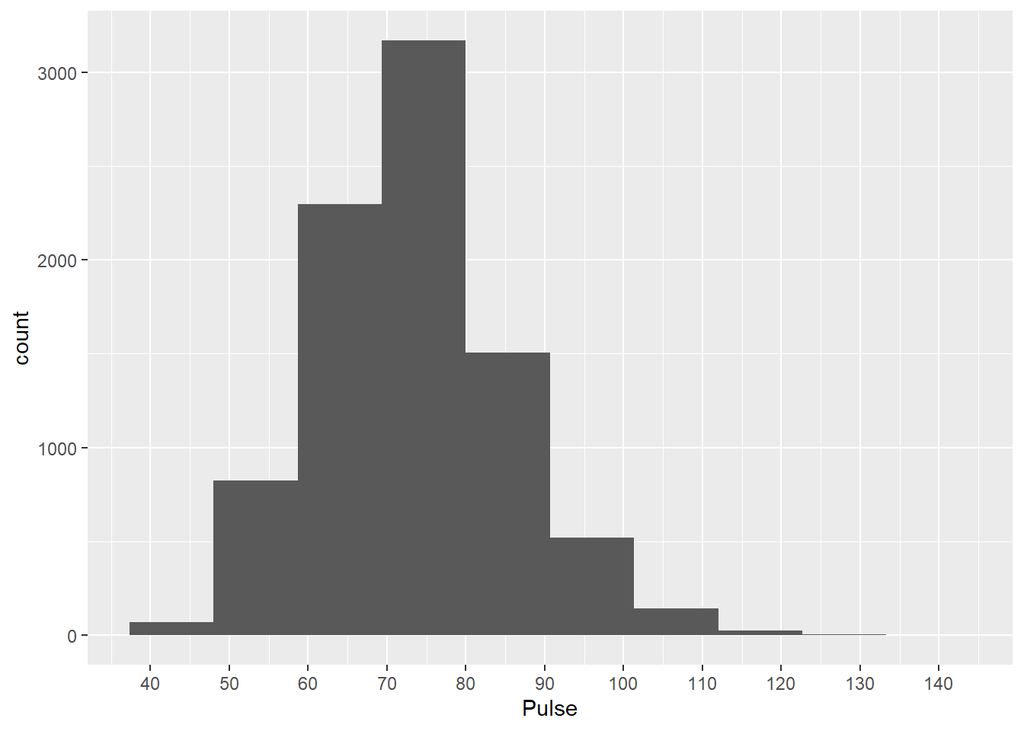

```r
# Notice the warning messages telling you that the number of bins was set to the default 30
# You can play around with the number of bins by putting bins = 10 (or another number of your choice)
# inside the brackets after geom_histogram

# slightly nicer histogram
# In this version, we will change the number of bins to 10 (same as in our frequency table)
# And we give details about the x-axis - we want it to run from 40 to 150,
# with a tick every 10 points
# Compare this histogram with the previous version using the arrows on the Plots panel

NHANES %>%
  ggplot(aes(x = Pulse)) +
  geom_histogram(bins = 10) +
  scale_x_continuous(breaks=seq(40,150,10))
```

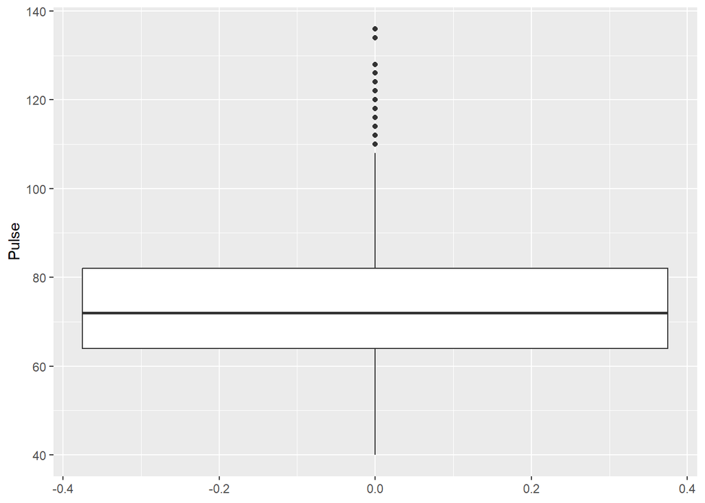

```r
# Boxplot ----
# This is the default boxplot, and already looks fine
# Notice how we put the Pulse variable on the y-axis (rather than x-axis, as we did in histogram)
# It's a convention that boxplots are usually vertical rather than horizontal

NHANES %>%
  ggplot(aes(y = Pulse)) +
  geom_boxplot()
```

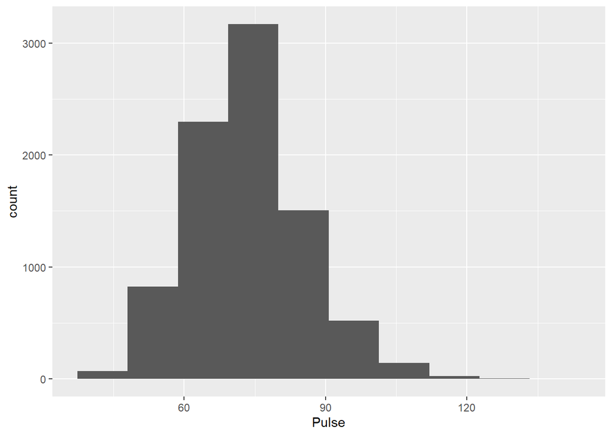

```r
# Multiple distributions at once

# Let's go back to our simple histogram, with 10 bins:
NHANES %>%
  ggplot(aes(x = Pulse)) +
  geom_histogram(bins = 10)
```

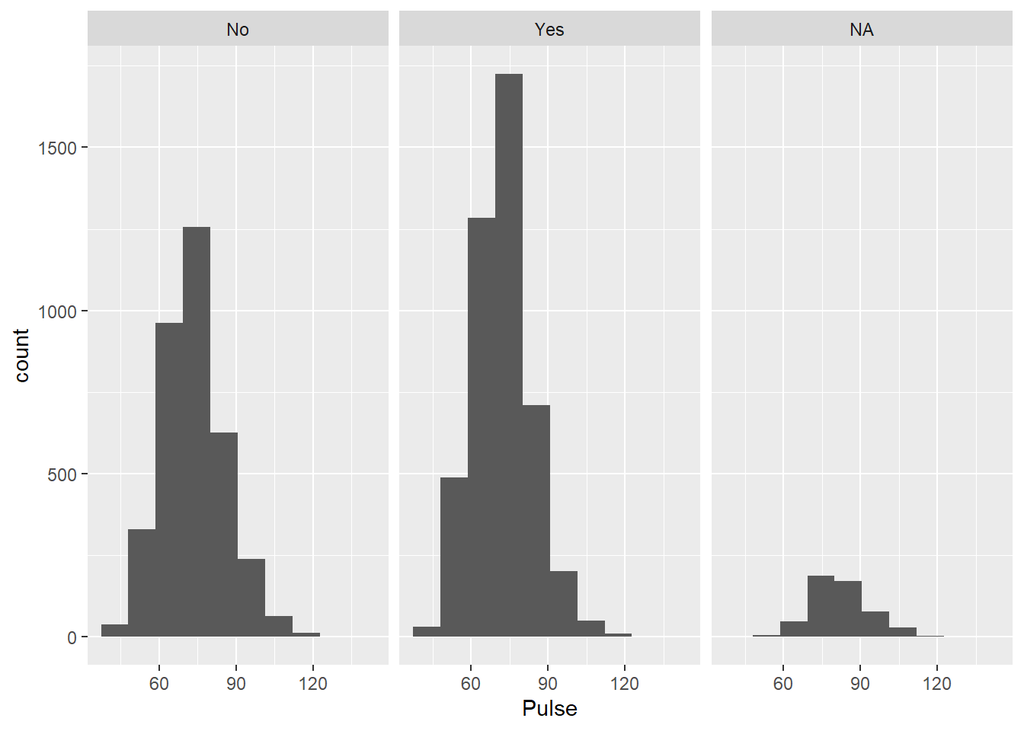

```r
# Facet wrap - multiple pulse distibuiton ----
# Now we would like to see the distribution of pulse depending on the level of physical activity
# We can do this using a function called facet_wrap
# Run the chunk below and see what happens:

NHANES %>%
  ggplot(aes(x = Pulse)) +
  geom_histogram(bins = 10) +
  facet_wrap(facets = NHANES$PhysActive)
```

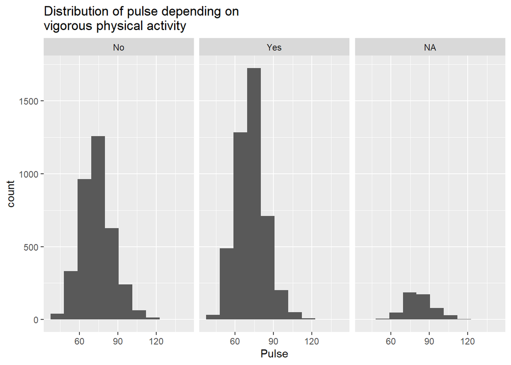

```r
# You should see 3 separate histograms, each for a different level of the PhysActive variable
# (and a third one for people who had missing data on that variable)

# improve the visulatization with descreption ----
# Let's add a nice title to this graph:
NHANES %>%
  ggplot(aes(x = Pulse)) +
  geom_histogram(bins = 10) +
  facet_wrap(facets = NHANES$PhysActive) +
  labs(title = "Distribution of pulse depending on \nvigorous physical activity")
```

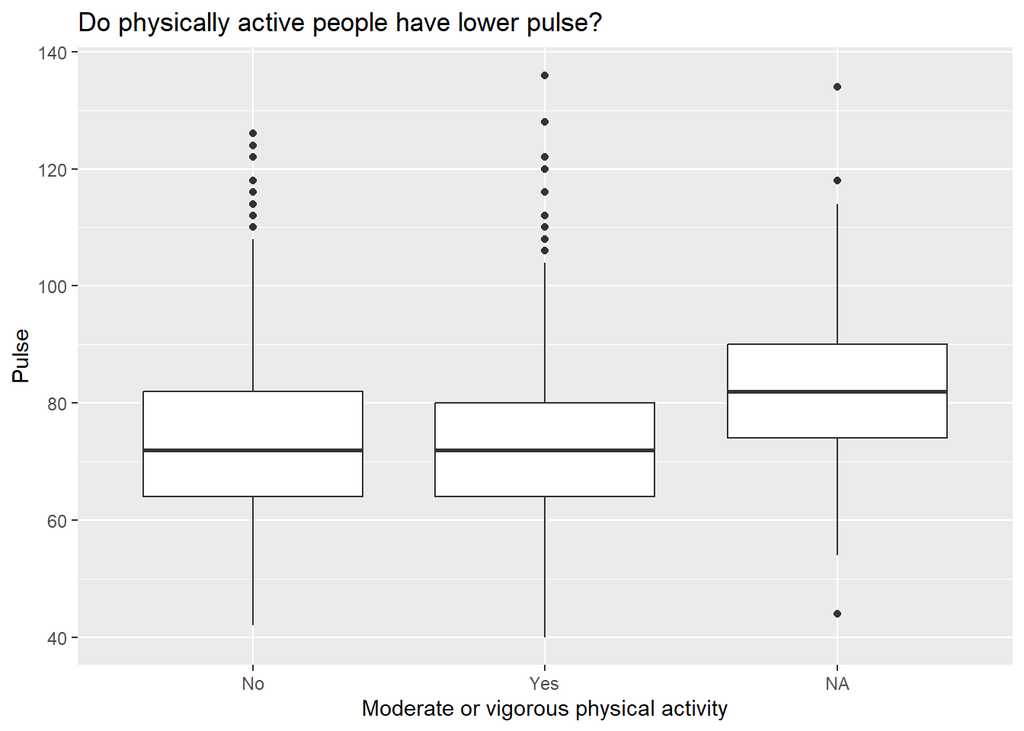

```r
# Let's do a similar exploration using a boxplot: ----
NHANES %>%
  ggplot(aes(x = PhysActive, y = Pulse)) +
  geom_boxplot() +
  labs(title = "Do physically active people have lower pulse?",
       x = "Moderate or vigorous physical activity")
```

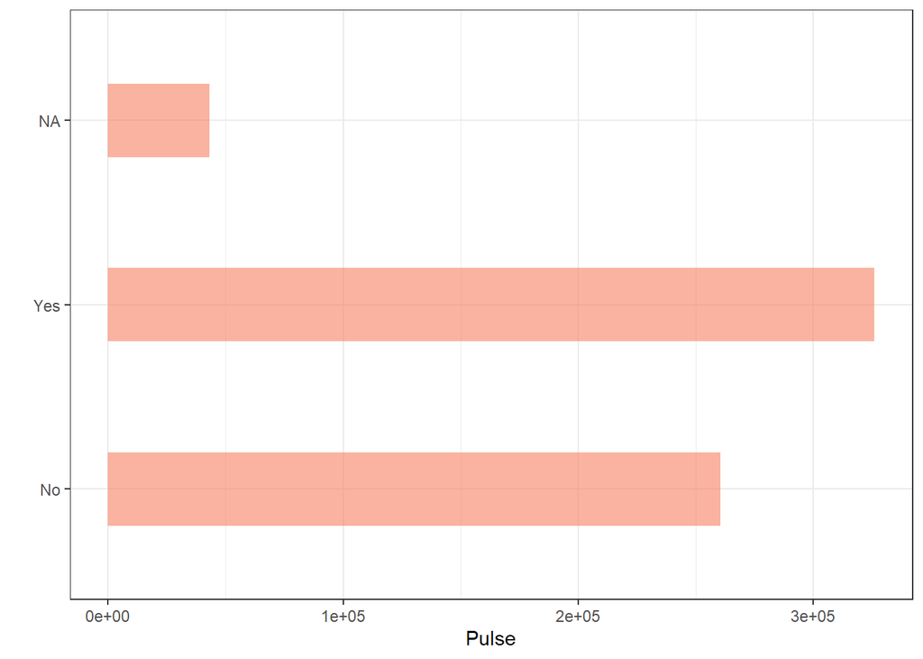

```r
# Notice that we put Pulse on the y-axis, and level of physical activity on the x axis
# to stick with the convention **that boxplots are vertical**
# We've added a title and a label to the x-axis

library(dplyr)
library(forcats)
NHANES %>%
  ggplot(aes(x = PhysActive, y = Pulse)) +
  geom_bar(stat="identity", fill="#f68060", alpha=.6, width = .4) +
  coord_flip() +
  xlab("") +
  theme_bw()
```

### WK1 - TOPIC 3 NORMAL DISTRIBUTION and its main characterisitics

histogram visualized distibution of numerical values * Normal distribution is common in nature * scaling histogram - Y axix is usually first the count * illusterating distibution > we can make Y axix is a density > so we can calcuate the area in an area to it is the pobability of data in a specific area  
* curve >> smoothing hte distogram >> proability density funciton  
* we calcuate the proability for being in between the two lines in the last plot >> if we know the mathematical equation * Normal distibution ** symmetric ** unimodal (one mode) ** mean, meedian and mode <- same value ** describe the curve using an equation **go for it more** ** emperical rule >> m >> M+1sd >> m+2sd >> m+3sd (alpha) >> 68% >> 95% >> 99.7

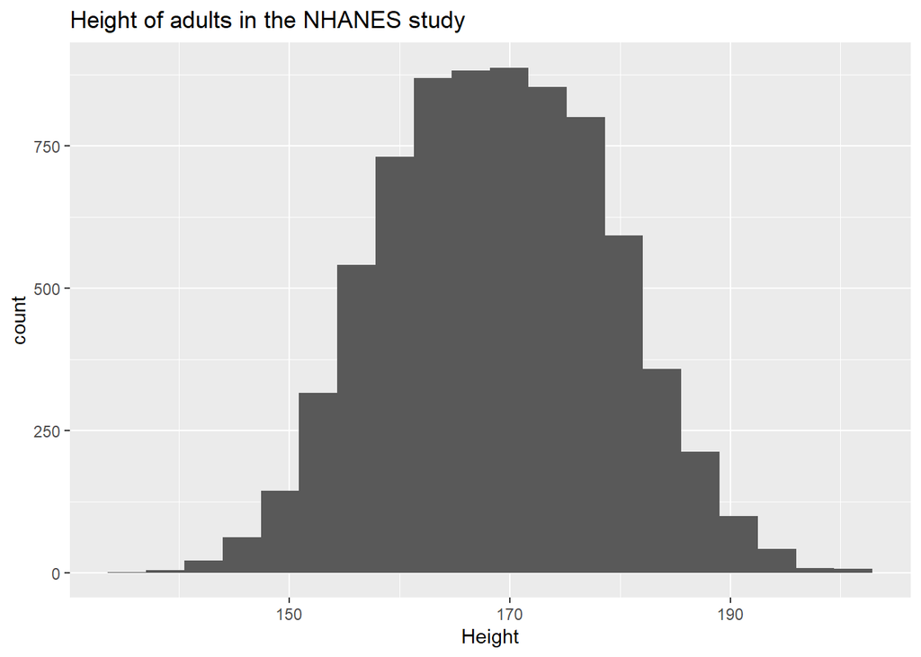

```r
# We'll start with a histogram of height from the NHANES dataset ----
# I picked height because I assume it will be normally distributed among adults

NHANES %>%
  filter(Age > 17) %>% # filter the data to only include adults (18 or above)
  ggplot(aes(x = Height)) +
  geom_histogram(bins = 20) + # 20 bins was just a guess - you can try a different number
  labs(title = "Height of adults in the NHANES study") # adding a title is always a good idea
```

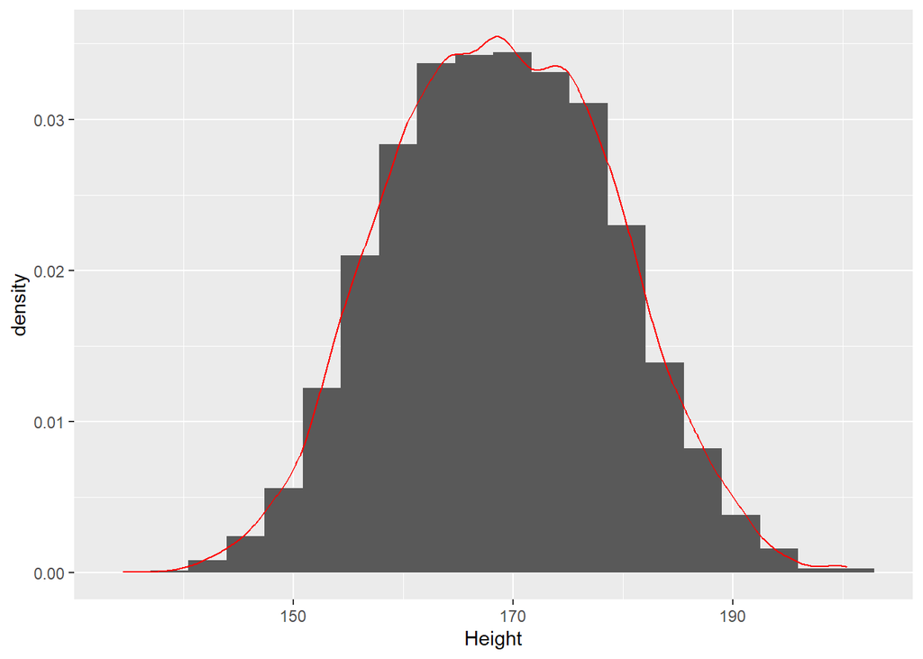

```r
# adding the probability density function ----
# notice the change on line 22 - we're scaling the histogram to have density instead of count
# and we are adding a probability density line on line 23

NHANES %>%
  filter(Age > 17) %>%
  ggplot(aes(x = Height)) +
  geom_histogram(aes(y=..density..), bins = 20) +  # scale histogram y-axis
  geom_density(col = "red")
```

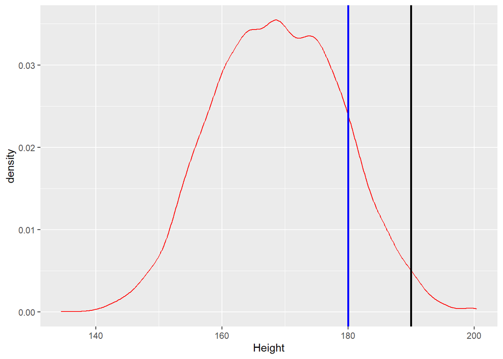

```r
# This is how we added the blue and black line on slide 10 ----
# geom_vline stands for a vertical line
# we have to specify the intercept, colour and size

NHANES %>%
  filter(Age > 17) %>%
  ggplot(aes(x = Height)) +
  geom_density(col = "red") +
  geom_vline(aes(xintercept = 180), color="blue", size=1) +
  geom_vline(aes(xintercept = 190), color="black", size=1)
```